# Strategic Information Security Risk Analysis

Evaluator Report Sample

Evaluator toolkit (https://github.com/davidski/evaluator)

# Summary

> This report is based upon 10,000 simulations performed over 56 risk scenarios and 60 capabilites on 2017-01-27 13:08:41-0800.

Total yearly losses are estimated to exceed the organization’s major risk threshold ($50,000,000) 0% of the time.

The following table shows the maximum, 95th percentile Value at Risk (VaR), mean, and minimum annual losses.

Total Annual Loss Exposure

| Value at Risk | Maximum Loss | Mean Loss | Minimum Loss |
| --- | --- | --- | --- |
| $18,947,917 | $29,769,853 | $12,932,735 | $4,102,278 |

## Loss Exceedance Curve

The following figure shows the frequency total losses will exceed a given threshold during a given year. The 80% line shows that a loss of at least $4,381,248 occurs every four out of five years without outliers, and at at least $9,925,870 when the outliers are included.

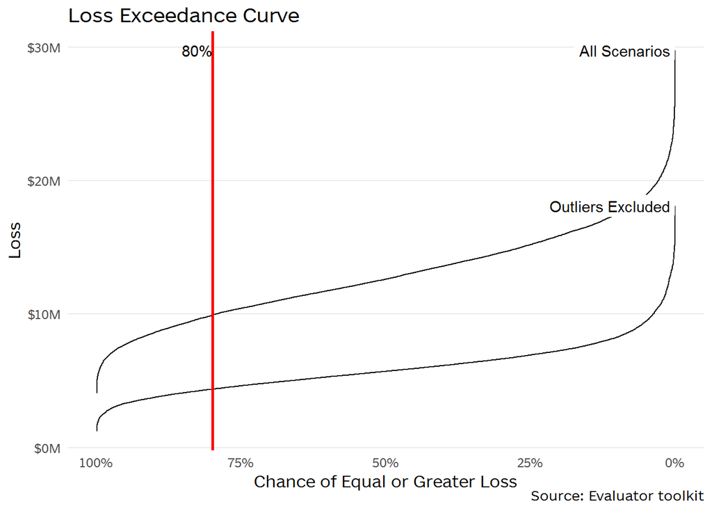

Loss Exceedance Curve

## Risk By Domain

The top three domains by loss size are Information Security Incident Management (IM), Information Security Management Program (ISMP), and Compliance (COMP).

Annual Loss by Domain

| Domain | Value at Risk | Maximum | Mean (Average) | Minimum | Standard Deviation |
| --- | --- | --- | --- | --- | --- |
| Information Security Incident Management (IM) | $6,733,234 | $9,348,031 | $4,454,852 | $1,135,132 | $1,296,758 |
| Information Security Management Program (ISMP) | $3,945,463 | $5,859,355 | $2,489,927 | $600,745 | $808,071 |
| Compliance (COMP) | $3,457,403 | $5,663,027 | $2,125,697 | $289,584 | $744,211 |
| Organization of Information Security (ORG) | $3,348,106 | $5,929,085 | $1,933,658 | $5,897 | $785,068 |
| Physical and Environmental Security (PHY) | $2,024,794 | $4,666,166 | $177,079 | $0 | $670,772 |
| Human Resources Security (HR) | $1,135,399 | $1,862,870 | $632,037 | $25,467 | $281,025 |
| Access Control (AC) | $1,085,733 | $1,745,394 | $606,893 | $25,205 | $268,729 |
| Communications and Operations Management (OPS) | $526,110 | $1,251,512 | $247,111 | $35,028 | $145,292 |
| Privacy Practices (PRI) | $445,723 | $1,100,836 | $153,801 | $0 | $148,473 |
| Asset Management (ASSET) | $70,526 | $376,467 | $28,222 | $449 | $33,248 |
| Security Policy (POL) | $151 | $9,542 | $177 | $0 | $939 |
| Information Systems Acquisition, Development, and Maintenance (ADM) | $0 | $358,378 | $3,115 | $0 | $21,846 |
| Business Continuity Management (BC) | $0 | $4,175,342 | $76,099 | $0 | $435,751 |
| Risk Management (RISK) | $0 | $379,457 | $4,066 | $0 | $24,765 |

### Simulation Outcomes by Domain

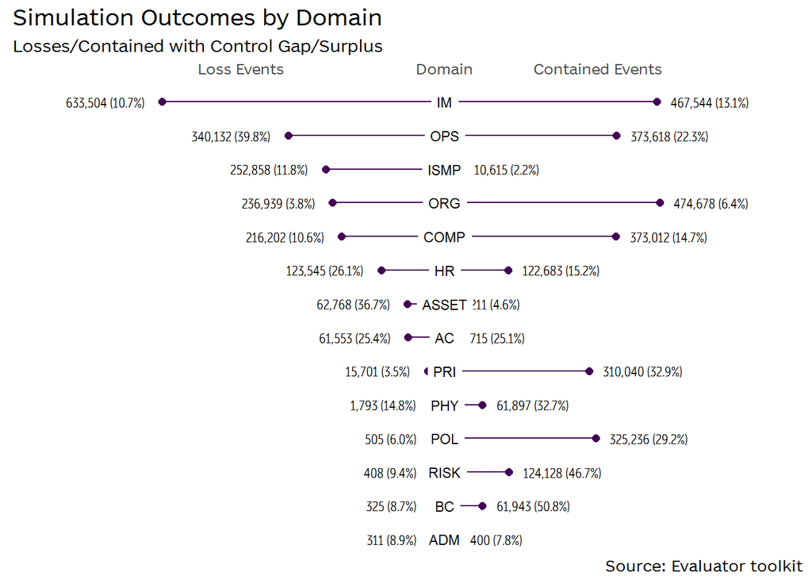

## Top Risk Scenarios

The leading scenarios, measured by value at risk, are:

Top Five Scenarios by Value at Risk

| Domain ID | Scenario | Median Annual Loss | Value at Risk |
| --- | --- | --- | --- |
| IM | Inadequate response results in inappropriate internal use of data. | $2,479,429 | $4,037,038 |
| ISMP | Key areas of the security program are not managed. | $2,420,975 | $3,945,463 |
| COMP | External attackers locate previously unknown weaknesses in the information security program not revealed through internal controls. | $1,888,241 | $3,143,758 |
| IM | Undetected and unremediated security incidents result in unmitigated access. | $1,186,201 | $2,145,995 |
| PHY | Damage to or loss of physical facility through natural disaster. | $0 | $1,881,421 |

The full list of evaluated risk scenarios is located in Appendix A.

## Key Capability Weaknesses

Threats most frequently overcome the control capabilities, resulting in losses, in the domains of Asset Management (ASSET), Access Control (AC), and Information Security Management Program (ISMP).

Domain Weaknesses

| Domain | Succesful Threat Events | Control Gap | Surplus Control Strength |
| --- | --- | --- | --- |
| Asset Management (ASSET) | 99.7% | 36.7% | 4.6% |
| Access Control (AC) | 98.9% | 25.4% | 25.1% |
| Information Security Management Program (ISMP) | 96.0% | 11.8% | 2.2% |
| Information Security Incident Management (IM) | 57.5% | 10.7% | 13.1% |
| Human Resources Security (HR) | 50.2% | 26.1% | 15.2% |
| Communications and Operations Management (OPS) | 47.7% | 39.8% | 22.3% |
| Information Systems Acquisition, Development, and Maintenance (ADM) | 43.7% | 8.9% | 7.8% |
| Compliance (COMP) | 36.7% | 10.6% | 14.7% |
| Organization of Information Security (ORG) | 33.3% | 3.8% | 6.4% |
| Privacy Practices (PRI) | 4.8% | 3.5% | 32.9% |
| Physical and Environmental Security (PHY) | 2.8% | 14.8% | 32.7% |
| Business Continuity Management (BC) | 0.5% | 8.7% | 50.8% |
| Risk Management (RISK) | 0.3% | 9.4% | 46.7% |
| Security Policy (POL) | 0.2% | 6.0% | 29.2% |

## Focus Risk Scenarios

### Key Scenario A

Scenario: Unauthorized access to or use of information and systems.

Scenario 51 Overview

| Value at Risk | $1,085,733 |
| --- | --- |
| Vulnerability (% of events resulting in loss) | 100% |
| Mean Control Gap | 25.4% |
| Maximum Annual Loss | $1,745,394 |
| Median Annual Loss | $583,581 |
| Maximum Single Loss | $449,486 |
| Median Single Loss | $82,655 |

### Key Scenario B

Scenario: External attackers locate previously unknown weaknesses in the information security program not revealed through internal controls.

Scenario 11 Overview

| Value at Risk | $3,143,758 |
| --- | --- |
| Vulnerability (% of events resulting in loss) | 74.8% |
| Mean Control Gap | 11.4% |
| Maximum Annual Loss | $4,990,522 |
| Median Annual Loss | $1,888,241 |
| Maximum Single Loss | $466,000 |
| Median Single Loss | $81,069 |

## Outliers

Some scenarios have values at risk that are significantly higher than the population mean of $439,602. To avoid distorting the overall analysis, some sections exclude these outliers. Graphs and tables are clearly noted when they display filtered data. The outlier scenarios are:

| Domain ID | ID | Description | Value at Risk | Median | Maximum |
| --- | --- | --- | --- | --- | --- |
| IM | 50 | Inadequate response results in inappropriate internal use of data. | $4,037,038 | $2,479,429 | $6,105,365 |
| ISMP | 54 | Key areas of the security program are not managed. | $3,945,463 | $2,420,975 | $5,859,355 |
| COMP | 11 | External attackers locate previously unknown weaknesses in the information security program not revealed through internal controls. | $3,143,758 | $1,888,241 | $4,990,522 |

# Methodology

The security strategic risk assessment process is based upon the industry standard OpenFAIR methodology. Expert opinion is polled on the threats, capabilities, and probable loss magnitudes associated with key risk scenarios. This information is used to create a Monte Carlo model, generating a a dollar-quantified risk exposure for each tracked risk.

A Value at Risk (VaR) model is used to rank risks. As VaR is a summary statistic (the 95 percentile), different groupings are not directly comparable. For instance, the VaR totals for domain summary will not match precisely with the VaR total for the simulation, nor will either of those statistics match the VaR calculated at the scenario level. VaRs should only be compared at a consistent level of grouping.

## Domains

The security program is divided into 14 domains as a framework for systematically reviewing risk. These domains are:

Domain Listing

| Domain ID | Domain |
| --- | --- |
| AC | Access Control |
| ASSET | Asset Management |
| BC | Business Continuity Management |
| OPS | Communications and Operations Management |
| COMP | Compliance |
| HR | Human Resources Security |
| IM | Information Security Incident Management |
| ISMP | Information Security Management Program |
| ADM | Information Systems Acquisition, Development, and Maintenance |
| ORG | Organization of Information Security |
| PHY | Physical and Environmental Security |
| PRI | Privacy Practices |
| RISK | Risk Management |
| POL | Security Policy |

## Capabilities

The security team and key subject matter experts formed a consensus opinion on the maturity level of the 60 capabilities which make up the 14 security program domains. The team assessed each capability against a five-level capability maturity model (patterned after the [CMMI](http://cmmiinstitute.com/) model), ranging from initial (level 1) through optimizing (level 5). These capability ratings are used to create a distribution of simulated capability effectiveness over the course of a year, ranging from 100% (completely effective) to 0% (completely ineffective).

The full capabilities catalog, including the ratings assigned, is included as Appendix B.

## Risk Scenarios

Each domain of the security program has a list of multiple risk scenarios which that portion of program is meant to address. These scenarios consists of:

1. The threat community (e.g. internal workforce members, nature, partners) performing the action.
2. The action taken by the threat actor.
3. The program capabilities that resist harm by the threat and actor.
4. The consequences of the action, should it occur.

Working against the scenario list, qualitative ratings are assigned for the frequency of the threat acting against the institution, the capabilities of the threat, and the size of the loss should the attack overcome the security program’s capabilities.

All Scenarios

| Scenario ID | Scenario | Actor | Action Frequency | Impact |
| --- | --- | --- | --- | --- |
| AC - 48 | Unauthorized access to or use of information and systems results in inappropriate use by internal users. | Organizational Internal Users | Rare | Medium |
| AC - 51 | Unauthorized access to or use of information and systems. | Organizational Vendors | Occasional | Medium |
| ADM - 56 | Malfunction of business application and system software. | Computer Systems | Rare | Medium |
| ASSET - 45 | Loss of information assets due to misclassification and non-classification. | Organizational Workforce | Occasional | Low |
| ASSET - 46 | Misclassification due to data aggregation. | Organizational Workforce | Rare | Low |
| ASSET - 47 | Lack of accountability for critical information and systems results in inappropriate control and inventory. | Organizational IT | Rare | Medium |
| BC - 31 | Business disruption and non-recovery of data. | Organizational IT | Occasional | Medium |
| BC - 55 | Damage to or loss of information system due to natural disaster at physical facility. | Nature | Rare | High |
| COMP - 9 | New or changing privacy regulations are not implemented in organizational IT systems. | External Regulators | Occasional | High |
| COMP - 10 | Internal workforce members execute financial fraud, embezzlement, or information theft made possible through lack of internal controls. | Organizational Workforce | Frequent | Medium |
| COMP - 11 | External attackers locate previously unknown weaknesses in the information security program not revealed through internal controls. | External Attackers | Frequent | Medium |
| COMP - 12 | External auditors find compliance issues with regulations and standards not identified via internal processes. | External Auditors | Rare | Medium |
| HR - 24 | Changing cultural norms on the use of data combined with insufficient education results in privacy violations. | Organizational Workforce | Occasional | Low |
| HR - 25 | Through insufficient training, workforce members cannot identify (or fail to report) potential information security incidents, resulting in loss from undetected attacks. | Organizational Workforce | Occasional | Medium |
| HR - 26 | Misuse of information assets or user errors (data entry errors, omissions, inadvertent acts or carelessness). | Organizational Workforce | Occasional | Medium |
| HR - 27 | Successful social engineering attacks result in information or financial loss. | External Attacker | Occasional | Low |
| IM - 19 | Organizational security team cannot identify nor correct root cause of information breach, resulting in rework. | Organizational Security Team | Occasional | Low |
| IM - 20 | Lack of incident handling results in noncompliance with laws, regulations, and contractual agreements. | Organizational Security Team | Rare | Medium |
| IM - 21 | Failure to address security incidents results in reputation loss. | Organizational Security Team | Occasional | Medium |
| IM - 22 | Undetected and unremediated security incidents result in unmitigated access. | External Attacker | Frequent | Medium |
| IM - 23 | Inadequate investigation results in inappropriate notifications. | External Attacker | Occasional | Medium |
| IM - 37 | Destruction, misuse, or modification of information assets through breach of technical controls. | External Attacker | Rare | Medium |
| IM - 38 | Eroding network boundaries result in lack of defenses on systems. | External Attacker | Rare | Medium |
| IM - 39 | External attackers breach technical controls and gain unauthorized access to systems and networks. | External Attacker | Frequent | Low |
| IM - 40 | Unintended consequence of implemented information security controls on workforce or connected devices. | Organizational IT | Occasional | Medium |
| IM - 50 | Inadequate response results in inappropriate internal use of data. | Internal Attacker | Frequent | Medium |
| IM - 52 | Inability to respond to litgation holds. | External Legal Authority | Rare | Medium |
| IM - 53 | Inability to respond to HR investigations results in avoidable adverse judgements. | Organizational HR Team | Occasional | Low |
| ISMP - 54 | Key areas of the security program are not managed. | Organizational Leadership | Frequent | Medium |
| OPS - 28 | Unknown attack intelligence results in undetected events. | External Attacker | Frequent | Low |
| OPS - 29 | Unknown incidence of security breach | External Attacker | Occasional | Low |
| OPS - 30 | Lack of monitoring demonstrates failure to take due care, resulting in non-compliance with associated laws and regulations. | External Auditor | Occasional | Medium |
| OPS - 32 | Changing or adding software without authorization results in system performance or data disclosure. | Organizational IT | Frequent | Medium |
| OPS - 33 | Malfunction of business application and system software. | Computer Systems | Rare | Low |
| OPS - 34 | Lack of ability to respond to targeted malware (Trojan horse, spyware, BOTS, worms, and viruses) results in compromise of data assets. | External Attacker | Rare | Medium |
| OPS - 35 | Breach through technical controls results in reportable significant unauthorized disclosure of data. | External Attacker | Rare | Low |
| OPS - 36 | Unforeseen effect of changes to software, computer, and communications equipment. | Organizational IT | Occasional | Low |
| ORG - 1 | Inadequate human resources are available to execute the informaton security strategic security plan. | Organizational Leadership | Frequent | Medium |
| ORG - 2 | Budget does not adequately support the information security strategic plan. | Organizational Leadership | Frequent | Medium |
| ORG - 3 | Competing priorities within the institution results in inability to execute the information security strategic security plan. | Organizational Leadership | Occasional | Medium |
| ORG - 4 | Increased negligence by workforce members due to lack of appropriate delegated authority and security support. | Organizational Workforce | Occasional | Medium |
| ORG - 5 | The information security function implements a strategy that has unanticipated consequences on the insitution, interfering with other stated business objectives. | Organizational Security Team | Occasional | Low |
| PHY - 41 | Damage to or loss of information systems and network services through terror-related physical attack. | External Attacker | Rare | Medium |
| PHY - 42 | Damage to or loss of physical facility through natural disaster. | Nature | Rare | High |
| PHY - 43 | Inappropriate release of information assets through physical disclosure. | Organizational Workforce | Rare | Medium |
| PHY - 44 | Theft or loss of physical assets. | External Attacker | Occasional | Medium |
| POL - 6 | Inconsistent interpretation or insecure actions by workforce. | Organizational Workforce | Frequent | Low |
| POL - 7 | Misuse of information assets. | Organizational Workforce | Occasional | Low |
| POL - 8 | Noncompliance with laws, regulations, and contractual agreements. | Organizational Workforce | Rare | Low |
| PRI - 17 | Internal user inappropriate use or misuse of information. | Organizational Workforce | Rare | Medium |
| PRI - 18 | Systemic noncompliance with privacy laws, regulations, and contractual agreements. | External Auditors | Occasional | Medium |
| PRI - 49 | Uncontrolled aggregation, proliferation, and use of data. | Organizational Workforce | Frequent | Medium |
| RISK - 13 | Inability to accurately forecast the consequences of adopted technologies or innovations. | Organizational IT | Rare | Low |
| RISK - 14 | Lack of risk management at leadership level results in inability to adjust strategic and tactical plans to changing external threat environment. | Organizational IT | Rare | Medium |
| RISK - 15 | Inability to understand specific threats related to attackers. | External Attackers | Occasional | Medium |
| RISK - 16 | Security failure or instability of providers or partners results in disclosure of organizational data. | Organizational Partners | Occasional | Medium |

## Simulation

Each of the qualitative labels is mapped to a set of parameters describing a beta pert distribution. These distributions are used to run 10,000 simulations over each risk scenario. Within a given simulation, a scenario is evaluated for potential losses using:

1. The number of times the threat actor acts against the organization.
2. The capabilities of the threat actor.
3. The difficulty the relevant controls present to the threat actor. For scenarios which have multiple controls applied, difficulty is the arithmetic mean of all the applicable controls.

This process generates several outputs:

- Threat Events: The number of times per year the threat presents itself
- Loss Events: The number of times the threat results in a loss (the threat overcomes the controls)
- Single Loss Expected (SLE): The size range of individual losses from each loss event
- Annual Loss Expected (ALE): The annualized sum of all individual losses.

Risk is the total annual expected losses across all scenarios within a given simulation.

## Assumptions

Each of the mappings from qualitative labels to quantitative parameters is displayed below.

### Threat Frequencies

Threat Frequencies

| Category | Low | Most Likely | High | Confidence |
| --- | --- | --- | --- | --- |
| Frequent | 10 | 24 | 52 | 4 |
| Occasional | 1 | 6 | 12 | 4 |
| Rare | 0 | 0.1 | 1 | 4 |

### Threat Capabilities

Threat Capabilities

| Category | Low | Most Likely | High | Confidence |
| --- | --- | --- | --- | --- |
| High | 50% | 60% | 98% | 3 |
| Medium | 33% | 50% | 60% | 3 |
| Low | 0% | 16% | 30% | 4 |

### Control Difficulties

Control Difficulties

| Category | Low | Most Likely | High | Confidence |
| --- | --- | --- | --- | --- |
| 5 - Optimized | 70% | 85% | 98% | 4 |
| 4 - Managed | 50% | 70% | 84% | 4 |
| 3 - Defined | 33% | 50% | 60% | 4 |
| 2 - Repeatable | 20% | 30% | 50% | 4 |
| 1 - Initial | 0% | 10% | 30% | 4 |

### Loss Magnitudes

Loss Magnitudes

| Category | Low | Most Likely | High | Confidence |
| --- | --- | --- | --- | --- |
| High | $1,000,000 | $2,000,000 | $5,000,000 | 4 |
| Medium | $10,000 | $20,000 | $500,000 | 4 |
| Low | $100 | $200 | $10,000 | 1 |

# Recommendations

## Analysis Improvement Opportunities

> The objective of a risk analysis is to provide better information and to reduce uncertainty in making strategic resource allocation decisions. As part of this decision process, consider if additional information is needed to perform a better risk analysis. Additional data or higher confidence data may reduce the variability in your projections.

Typical areas for additional data include:

- Control Effectiveness Refinement - Can we benchmark our controls against other organizations or otherwise better understand the maturity of our capabilities?
- Scenario Refinement - Have we clearly identified the threat communities, their capabilities and their frequency of action?
- Loss Magnitude Refinement - Can we leverage either our own incident data or data publicly (such as the VCDB) or semi-publicly (industry CIRTs) to better understand our potential economic losses?

# Supplemental Analysis

Scenarios should be treated based upon size of the value at risk (VaR) calculation. Ranking scenarios by VaR creates a prioritized list of scenarios to address.

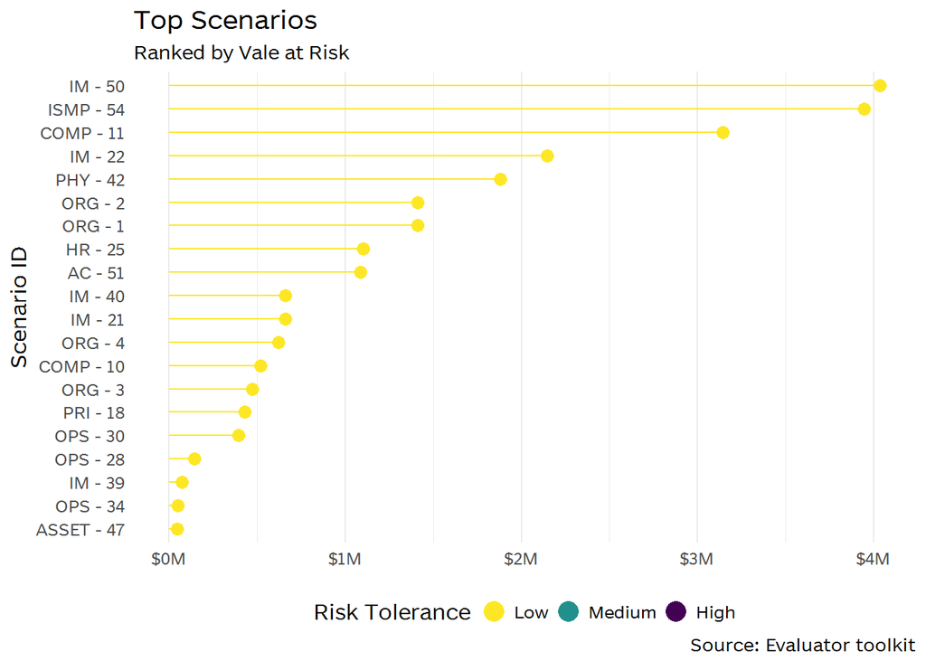

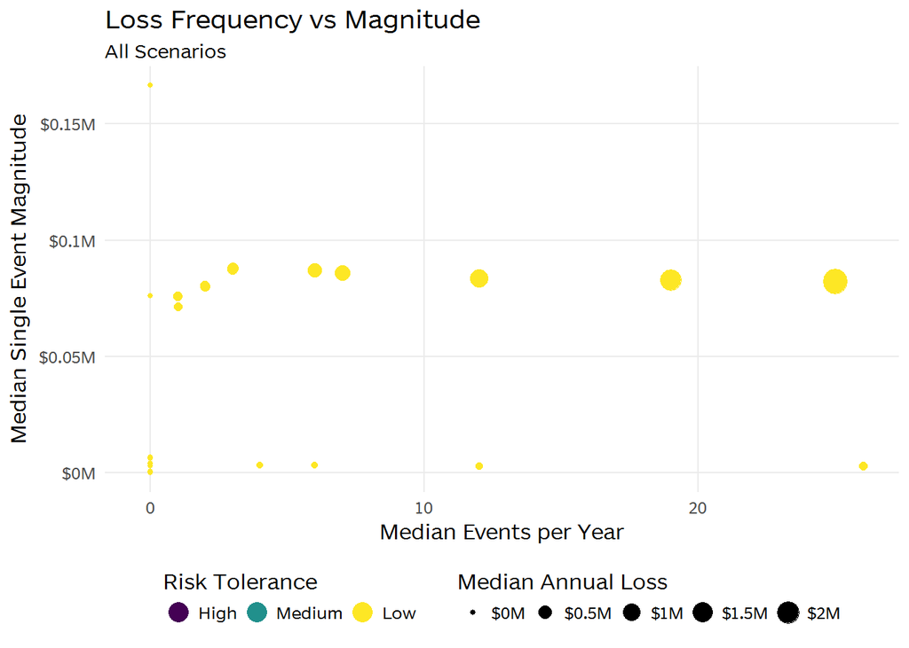

## Loss Frequency

Overall frequency of loss events is displayed at the domain and at the scenario level.

### Domain-Level Loss Frequency

The number of loss events a domain experiences is the sum of all of the loss events which occur for each scenario. To calculate the domain level loss frequency, first summarize all of the events at the simulation level, then roll up to the scenario level finally performing domain level aggregations.

Full descriptive statistics are shown on a domain-level summary of loss events.

Loss Events by Domain Summary Statistics

| Domain_id | N | Mean | Sd | Median | Trimmed | Mad | Min | Max | Range | Skew | Kurtosis | Se |
| --- | --- | --- | --- | --- | --- | --- | --- | --- | --- | --- | --- | --- |
| AC | 10000 | 6.1553 | 2.0859092 | 6 | 6.143125 | 2.9652 | 1 | 12 | 11 | 0.08913991 | -0.60069979 | 0.020859092 |
| ADM | 10000 | 0.0311 | 0.1735967 | 0 | 0.000000 | 0.0000 | 0 | 1 | 1 | 5.40163716 | 27.18040211 | 0.001735967 |
| ASSET | 10000 | 6.2768 | 2.1435581 | 6 | 6.259875 | 2.9652 | 1 | 13 | 12 | 0.13008196 | -0.50779300 | 0.021435581 |
| BC | 10000 | 0.0325 | 0.1773327 | 0 | 0.000000 | 0.0000 | 0 | 1 | 1 | 5.27204728 | 25.79706222 | 0.001773327 |
| COMP | 10000 | 21.6202 | 6.8245153 | 21 | 21.348500 | 7.4130 | 4 | 47 | 43 | 0.35164024 | -0.31987932 | 0.068245153 |
| HR | 10000 | 12.3545 | 4.1930404 | 12 | 12.327625 | 5.9304 | 2 | 24 | 22 | 0.09225682 | -0.59619208 | 0.041930404 |
| IM | 10000 | 63.3504 | 16.4909495 | 62 | 62.828375 | 17.7912 | 20 | 125 | 105 | 0.29369201 | -0.32895966 | 0.164909495 |
| ISMP | 10000 | 25.2858 | 7.4648303 | 25 | 24.997000 | 7.4130 | 8 | 48 | 40 | 0.32269111 | -0.49831671 | 0.074648303 |
| OPS | 10000 | 34.0132 | 8.2270769 | 33 | 33.776125 | 8.8956 | 13 | 61 | 48 | 0.25925701 | -0.42114311 | 0.082270769 |
| ORG | 10000 | 23.6939 | 7.3413754 | 23 | 23.443125 | 7.4130 | 1 | 54 | 53 | 0.34699118 | 0.03812925 | 0.073413754 |
| PHY | 10000 | 0.1793 | 0.6624163 | 0 | 0.000000 | 0.0000 | 0 | 3 | 3 | 3.56881812 | 11.23517921 | 0.006624163 |
| POL | 10000 | 0.0505 | 0.2189853 | 0 | 0.000000 | 0.0000 | 0 | 1 | 1 | 4.10488855 | 14.85159523 | 0.002189853 |
| PRI | 10000 | 1.5701 | 1.2193583 | 1 | 1.468500 | 1.4826 | 0 | 8 | 8 | 0.73984675 | 0.41041775 | 0.012193583 |
| RISK | 10000 | 0.0408 | 0.1978365 | 0 | 0.000000 | 0.0000 | 0 | 1 | 1 | 4.64175337 | 19.54782913 | 0.001978365 |

The following figure shows the density of annualized loss events by domain. All domains are positive skewed, indicating loss events are clustered to the lower ranges.

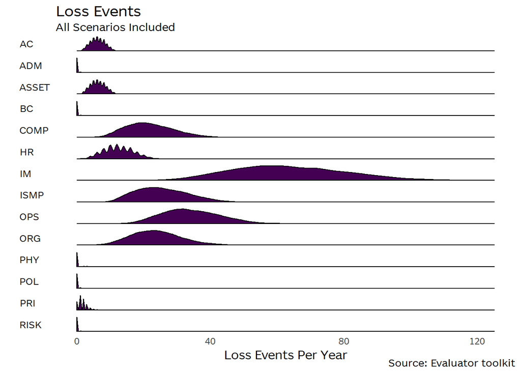

Loss Frequency by Domain

### Scenario-Level Loss Frequency

Looking at the number of loss events for each scenario helps identify scenarios worth closer scrutiny. A z-score is calculated for each mean loss frequency. Scenarios with a z-score of 2 or higher experience, on average, more frequent loss events.

The average loss frequency and the associated z-scores, are shown for all scenarios with an average loss frequency greater than 0.5 per year.

Scenario Mean Loss Frequency

| Scenario ID | Scenario | Mean Loss Events | Z Score |
| --- | --- | --- | --- |
| **OPS - 28** | **Unknown attack intelligence results in undetected events.** | **26** | **3.44** |
| **IM - 50** | **Inadequate response results in inappropriate internal use of data.** | **26** | **3.39** |
| **ISMP - 54** | **Key areas of the security program are not managed.** | **25** | **3.28** |
| **COMP - 11** | **External attackers locate previously unknown weaknesses in the information security program not revealed through internal controls.** | **20** | **2.44** |
| IM - 22 | Undetected and unremediated security incidents result in unmitigated access. | 13 | 1.37 |
| IM - 39 | External attackers breach technical controls and gain unauthorized access to systems and networks. | 13 | 1.37 |
| ORG - 1 | Inadequate human resources are available to execute the informaton security strategic security plan. | 8 | 0.61 |
| ORG - 2 | Budget does not adequately support the information security strategic plan. | 8 | 0.61 |
| HR - 25 | Through insufficient training, workforce members cannot identify (or fail to report) potential information security incidents, resulting in loss from undetected attacks. | 6 | 0.40 |
| OPS - 29 | Unknown incidence of security breach | 6 | 0.40 |
| ASSET - 45 | Loss of information assets due to misclassification and non-classification. | 6 | 0.40 |
| AC - 51 | Unauthorized access to or use of information and systems. | 6 | 0.40 |
| HR - 24 | Changing cultural norms on the use of data combined with insufficient education results in privacy violations. | 6 | 0.40 |
| IM - 19 | Organizational security team cannot identify nor correct root cause of information breach, resulting in rework. | 6 | 0.39 |
| ORG - 5 | The information security function implements a strategy that has unanticipated consequences on the insitution, interfering with other stated business objectives. | 4 | 0.10 |
| IM - 21 | Failure to address security incidents results in reputation loss. | 3 | -0.08 |
| IM - 40 | Unintended consequence of implemented information security controls on workforce or connected devices. | 3 | -0.08 |
| ORG - 4 | Increased negligence by workforce members due to lack of appropriate delegated authority and security support. | 3 | -0.11 |
| COMP - 10 | Internal workforce members execute financial fraud, embezzlement, or information theft made possible through lack of internal controls. | 2 | -0.24 |
| ORG - 3 | Competing priorities within the institution results in inability to execute the information security strategic security plan. | 2 | -0.26 |
| PRI - 18 | Systemic noncompliance with privacy laws, regulations, and contractual agreements. | 2 | -0.30 |
| OPS - 30 | Lack of monitoring demonstrates failure to take due care, resulting in non-compliance with associated laws and regulations. | 1 | -0.33 |

Note that larger than average loss events does not necessarily imply high risk, as the total size of all losses may be small. The size of losses is explored in the loss magnitude section. In the following figure, density diagrams are displayed for each individual scenario, allowing visual inspection of which scenarios occur with higher frequency.

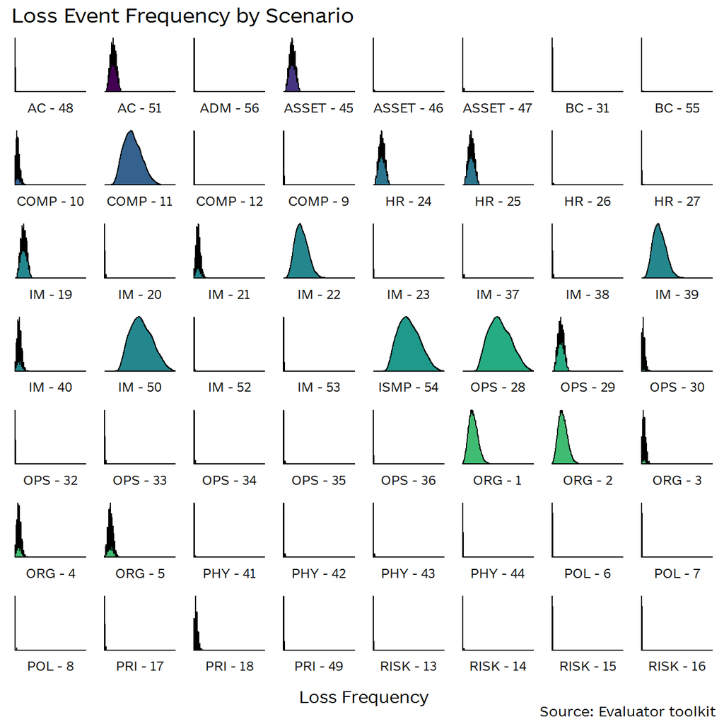

Loss Frequency by Scenario

## Loss Scenario Distributions

This figure shows the range of expected annual losses (ALE) for each scenario which has loss events.

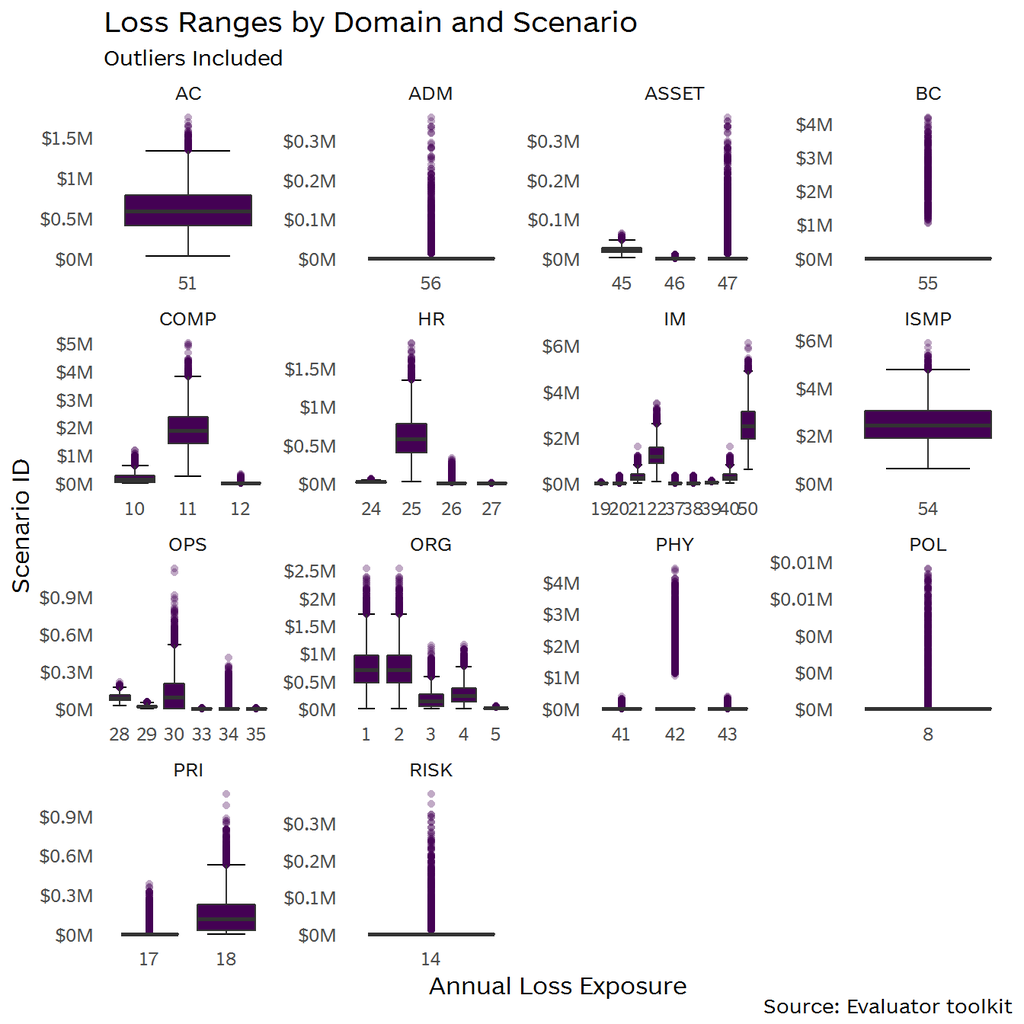

Annual Loss Range by Scenario

## Overall Risk

This section provides additional analysis into the organization’s security risk profile.

### Domain Level Risk Concentration

Heatmap of Value at Risk by domain.

[figure not shown]

This figure shows the range of expected annual losses by domain.

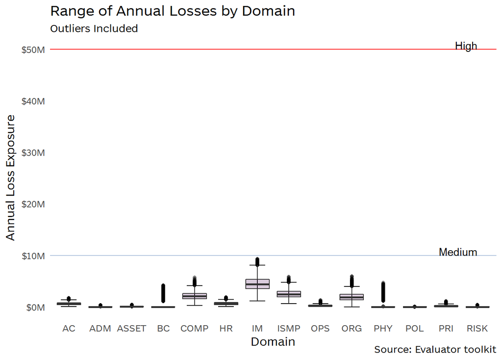

Risk by Domain

There are three domains (COMP and IM and ISMP) with annual loss ranges which far exceed the other scenarios. The domains that contain these scenarios are plotted separately to identify the outlying scenarios.

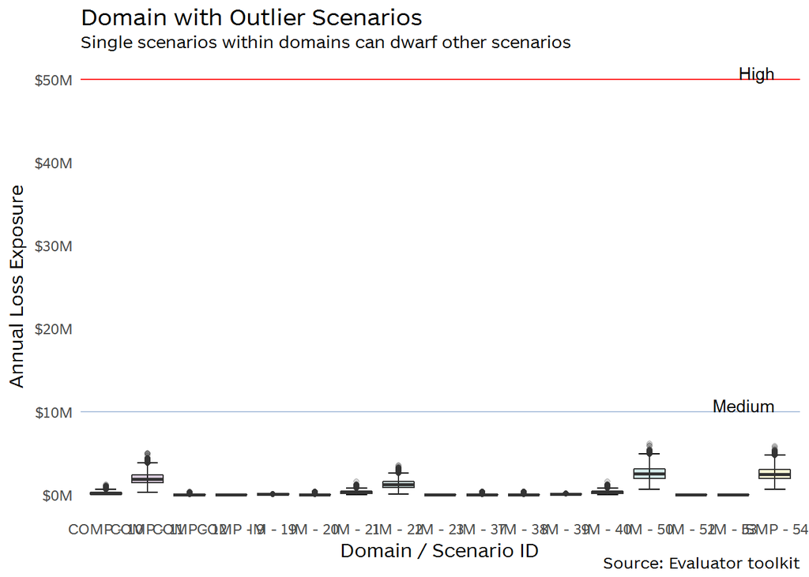

Risk for Outliers

### Risk by Domain without Outliers

Repeating the above plot across all the scenarios with the outliers removed allows examination of the remaining scenarios without distortion.

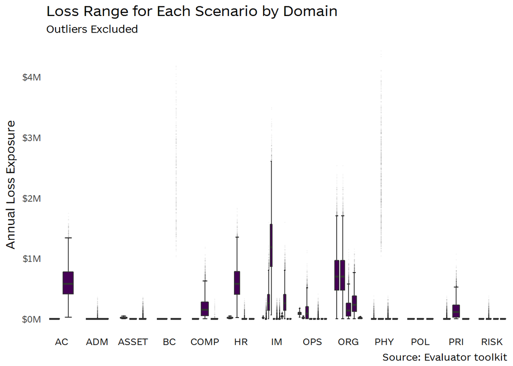

Annual Loss Excluding Outliers

### Alternative Risk Measures

Risk is reported as the 95th percentile Value at Risk measure across all of the simulated scenarios (sum of scenario ALEs). While this is generally the best representation of an organization’s risk exposure, alternative measures are possible. The following graph shows a histogram for all non-zero loss events with an overlaid density plot for both the standard VaR and the median ALE measure as an alternative.

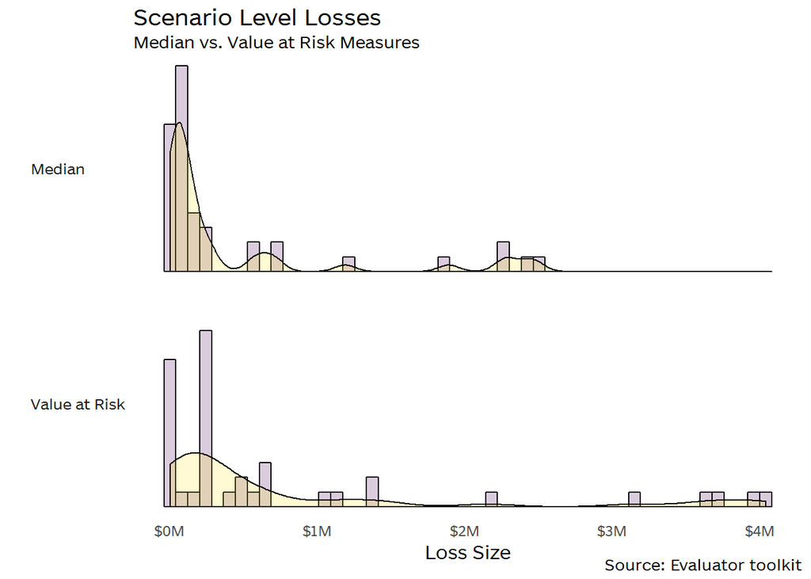

VaR vs Median

## Special Considerations

### Fragile Scenarios

Fragile scenarios are scenarios where a single control protects against loss. While the single control may be effective against the threat community, these scenarios should be reviewed to see if additional controls are warranted.

Fragile Scenarios

| Domain | Scenario ID | Scenario |
| --- | --- | --- |
| Information Security Incident Management (IM) | 52 | Inability to respond to litgation holds. |
| Information Security Incident Management (IM) | 53 | Inability to respond to HR investigations results in avoidable adverse judgements. |

# Appendicies

Additional details that are of tangential use are included as appendices.

## Appendix A

Scenario List

| Domain | Scenario | Median Annual Loss | Value at Risk |
| --- | --- | --- | --- |
| IM - 50 | Inadequate response results in inappropriate internal use of data. | $2,479,429 | $4,037,038 |
| ISMP - 54 | Key areas of the security program are not managed. | $2,420,975 | $3,945,463 |
| COMP - 11 | External attackers locate previously unknown weaknesses in the information security program not revealed through internal controls. | $1,888,241 | $3,143,758 |
| IM - 22 | Undetected and unremediated security incidents result in unmitigated access. | $1,186,201 | $2,145,995 |
| ORG - 1 | Inadequate human resources are available to execute the informaton security strategic security plan. | $698,152 | $1,410,613 |
| ORG - 2 | Budget does not adequately support the information security strategic plan. | $698,152 | $1,410,613 |
| AC - 51 | Unauthorized access to or use of information and systems. | $583,581 | $1,085,733 |
| HR - 25 | Through insufficient training, workforce members cannot identify (or fail to report) potential information security incidents, resulting in loss from undetected attacks. | $578,962 | $1,100,197 |
| IM - 21 | Failure to address security incidents results in reputation loss. | $258,797 | $659,074 |
| IM - 40 | Unintended consequence of implemented information security controls on workforce or connected devices. | $258,797 | $659,074 |
| ORG - 4 | Increased negligence by workforce members due to lack of appropriate delegated authority and security support. | $236,380 | $621,407 |
| COMP - 10 | Internal workforce members execute financial fraud, embezzlement, or information theft made possible through lack of internal controls. | $152,293 | $518,303 |
| ORG - 3 | Competing priorities within the institution results in inability to execute the information security strategic security plan. | $139,995 | $471,912 |
| PRI - 18 | Systemic noncompliance with privacy laws, regulations, and contractual agreements. | $115,292 | $429,481 |
| OPS - 30 | Lack of monitoring demonstrates failure to take due care, resulting in non-compliance with associated laws and regulations. | $91,090 | $394,639 |
| OPS - 28 | Unknown attack intelligence results in undetected events. | $88,272 | $142,359 |
| IM - 39 | External attackers breach technical controls and gain unauthorized access to systems and networks. | $41,806 | $73,947 |
| OPS - 29 | Unknown incidence of security breach | $20,560 | $37,303 |
| HR - 24 | Changing cultural norms on the use of data combined with insufficient education results in privacy violations. | $20,489 | $36,967 |
| ASSET - 45 | Loss of information assets due to misclassification and non-classification. | $20,481 | $37,566 |
| IM - 19 | Organizational security team cannot identify nor correct root cause of information breach, resulting in rework. | $20,168 | $37,238 |
| ORG - 5 | The information security function implements a strategy that has unanticipated consequences on the insitution, interfering with other stated business objectives. | $13,418 | $28,434 |
| PHY - 42 | Damage to or loss of physical facility through natural disaster. | $0 | $1,881,421 |
| OPS - 34 | Lack of ability to respond to targeted malware (Trojan horse, spyware, BOTS, worms, and viruses) results in compromise of data assets. | $0 | $48,710 |
| ASSET - 47 | Lack of accountability for critical information and systems results in inappropriate control and inventory. | $0 | $46,951 |
| PHY - 43 | Inappropriate release of information assets through physical disclosure. | $0 | $45,597 |
| IM - 20 | Lack of incident handling results in noncompliance with laws, regulations, and contractual agreements. | $0 | $42,771 |
| IM - 37 | Destruction, misuse, or modification of information assets through breach of technical controls. | $0 | $42,771 |
| IM - 38 | Eroding network boundaries result in lack of defenses on systems. | $0 | $42,771 |
| PRI - 17 | Internal user inappropriate use or misuse of information. | $0 | $36,474 |
| OPS - 33 | Malfunction of business application and system software. | $0 | $1,680 |
| OPS - 35 | Breach through technical controls results in reportable significant unauthorized disclosure of data. | $0 | $1,320 |
| POL - 8 | Noncompliance with laws, regulations, and contractual agreements. | $0 | $151 |
| ASSET - 46 | Misclassification due to data aggregation. | $0 | $5 |
| POL - 6 | Inconsistent interpretation or insecure actions by workforce. | $0 | $0 |
| POL - 7 | Misuse of information assets. | $0 | $0 |
| COMP - 9 | New or changing privacy regulations are not implemented in organizational IT systems. | $0 | $0 |
| COMP - 12 | External auditors find compliance issues with regulations and standards not identified via internal processes. | $0 | $0 |
| RISK - 13 | Inability to accurately forecast the consequences of adopted technologies or innovations. | $0 | $0 |
| RISK - 14 | Lack of risk management at leadership level results in inability to adjust strategic and tactical plans to changing external threat environment. | $0 | $0 |
| RISK - 15 | Inability to understand specific threats related to attackers. | $0 | $0 |
| RISK - 16 | Security failure or instability of providers or partners results in disclosure of organizational data. | $0 | $0 |
| IM - 23 | Inadequate investigation results in inappropriate notifications. | $0 | $0 |
| HR - 26 | Misuse of information assets or user errors (data entry errors, omissions, inadvertent acts or carelessness). | $0 | $0 |
| HR - 27 | Successful social engineering attacks result in information or financial loss. | $0 | $0 |
| BC - 31 | Business disruption and non-recovery of data. | $0 | $0 |
| OPS - 32 | Changing or adding software without authorization results in system performance or data disclosure. | $0 | $0 |
| OPS - 36 | Unforeseen effect of changes to software, computer, and communications equipment. | $0 | $0 |
| PHY - 41 | Damage to or loss of information systems and network services through terror-related physical attack. | $0 | $0 |
| PHY - 44 | Theft or loss of physical assets. | $0 | $0 |
| AC - 48 | Unauthorized access to or use of information and systems results in inappropriate use by internal users. | $0 | $0 |
| PRI - 49 | Uncontrolled aggregation, proliferation, and use of data. | $0 | $0 |
| IM - 52 | Inability to respond to litgation holds. | $0 | $0 |
| IM - 53 | Inability to respond to HR investigations results in avoidable adverse judgements. | $0 | $0 |
| BC - 55 | Damage to or loss of information system due to natural disaster at physical facility. | $0 | $0 |
| ADM - 56 | Malfunction of business application and system software. | $0 | $0 |

## Appendix B

Capability Listing

| Domain ID | Capability | Maturity |
| --- | --- | --- |
| AC | An identity and eligibility verification and registration process is defined, implemented, and maintained. | 2 - Repeatable |
| AC | An user and system account life cycle management process is defined, implemented, and maintained. | 3 - Defined |
| ADM | A flaw remediation process is defined, implemented, and maintained. | 3 - Defined |
| ADM | Secure application development life cycle or system development life cycle process is defined, implemented, and maintained. | 5 - Optimized |
| ASSET | A media & device handling and destruction process is defined, implemented, and maintained. | 1 - Initial |
| ASSET | A process to identify, inventory, assign ownership, and classify institutional information and information systems is defined, implemented, and maintained. | 1 - Initial |
| BC | Business disaster recovery and continuity plans are defined, implemented, and maintained. | 5 - Optimized |
| BC | Systematic backup process for critical information and software is defined, implemented, and maintained. | 3 - Defined |
| COMP | The information security program supports the privacy and information security compliance efforts, and business requirements. | 2 - Repeatable |
| COMP | Security compliance for all critical systems and networks is reviewed on a periodic basis. | 5 - Optimized |
| HR | Provide community outreach and collaborate with other organizations. | 2 - Repeatable |
| HR | Provide content and support for an information security and privacy awareness and education program for workforce members. | 3 - Defined |
| HR | Provide content review and support education efforts for all associated information security policies, including employee roles and responsibilities. | 1 - Initial |
| HR | Ensure workforce member security responsibilities are defined acording to security policy and communicated. | 2 - Repeatable |
| IM | An incident management process is defined, implemented, and maintained. | 1 - Initial |
| IM | Working relationships are established with third party contracted services, counter-intelligence experts, regional organizations, and researchers working in the field of incident response. | 1 - Initial |
| IM | Forensic investigation capabilities are established and available for incident response. | 4 - Managed |
| IM | Information security incidents are identified, responded to, mitigated, and documented. | 4 - Managed |
| IM | A process exists and is implemented for performing litigation holds. | 5 - Optimized |
| ISMP | An information security framework is established to guide the implementation of the information security program. | 2 - Repeatable |
| ISMP | Information security activities are supported by trained information security professionals. | 2 - Repeatable |
| ISMP | Roles and responsibilities are established and clearly defined for all information security positions. | 3 - Defined |
| OPS | Baseline measurement processes for application, system, and network activity are defined, implemented, and maintained. | 3 - Defined |
| OPS | Intrusion detection mechanism is defined, implemented, and maintained. | 1 - Initial |
| OPS | Logging process of network, systems, and applications is defined, implemented, and maintained. | 1 - Initial |
| OPS | Monitoring capability of critical systems is defined, implemented, and maintained. | 1 - Initial |
| OPS | A change and configuration management process is defined, implemented, and maintained. | 3 - Defined |
| OPS | An acceptable use standard is defined, implemented, and maintained. | 1 - Initial |
| OPS | Institutional hardware, software, system build, and maintenance standards are defined, implemented, and maintained. | 2 - Repeatable |
| OPS | Privacy and information security technical architecture standards are defined, implemented, and maintained. | 1 - Initial |
| OPS | A cryptographic process and data protection standard is defined, implemented, and maintained. | 2 - Repeatable |
| OPS | A remote and external access process is defined, implemented, and maintained. | 2 - Repeatable |
| OPS | An access authorization process for all authorized users and information systems is defined, implemented, and maintained. | 4 - Managed |
| OPS | An authentication mechanism for all authorized users and information systems is defined, implemented, and maintained. | 5 - Optimized |
| OPS | Network, system, and application level protection measures are defined, implemented, and maintained. | 3 - Defined |
| OPS | A data destruction or disposal process is defined, implemented, and maintained. | 5 - Optimized |
| ORG | A senior-level committee provides dedicated oversight for privacy and information security activities. | 5 - Optimized |
| ORG | Delegated authority is established for incident response. | 2 - Repeatable |
| ORG | Information security activities between departments are coordinated. | 4 - Managed |
| ORG | Senior management’s strategy and direction for the information security program is established and commitment is demonstrated. | 1 - Initial |
| ORG | Self-assessment of the information security program operations, activities, and strategic plan effectiveness is completed and reported on a periodic basis. | 4 - Managed |
| ORG | Verification of reasonable and appropriate information security controls are completed on a periodic basis. | 2 - Repeatable |
| ORG | Verification of reasonable and appropriate information security controls from third parties that have access to confidential information is completed on a periodic basis. | 2 - Repeatable |
| ORG | An active intelligence gathering program is defined, implemented, and maintained. | 4 - Managed |
| PHY | Physical access process for buildings that house critical IT facilities is defined, implemented, and maintained. | 3 - Defined |
| PHY | Physical protection process for buildings that house critical IT facilities is defined, implemented, and maintained. | 3 - Defined |
| PHY | Physical protection process for critical information systems and institutional information is defined, implemented, and maintained. | 5 - Optimized |
| PHY | The physical security plan is defined, implemented, and maintained. | 1 - Initial |
| POL | A designated group is set up to act as ombudsman for disputes and complaints regarding enterprise wide information security policies and standards. | 2 - Repeatable |
| POL | External authorities and industry trends are monitored for potential policy implications. | 5 - Optimized |
| POL | Policy compliance issues are documented, acknowledged, and periodically reviewed. | 2 - Repeatable |
| POL | The information security policies are defined, implemented, maintained, and support the business requirements and relevant regulations and laws. | 2 - Repeatable |
| PRI | Online privacy policy and terms of use statements are defined, implemented, and maintained. | 2 - Repeatable |
| PRI | Security controls and responsibility for information privacy are defined, implemented, and maintained. | 1 - Initial |
| PRI | Storage and transmission of confidential information is limited to minimum necessary, de-identified when possible, and deleted when no longer needed. | 5 - Optimized |
| PRI | The privacy program and policies are defined, implemented, and maintained in cooperation with the Privacy Officer and support the business requirements and relevant regulations and laws. | 5 - Optimized |
| RISK | An appropriate risk identification and treatment program related to the access and use of confidential information is defined, implemented, and maintained. | 2 - Repeatable |
| RISK | Results of risk assessments, including any residual risks exposures, are acknowledged by the risk owners. | 3 - Defined |
| RISK | Risk assessments are completed on all critical applications, systems, and networks on a periodic basis. | 5 - Optimized |
| RISK | Summary risk conditions of the enterprise information security program are provided to senior management. | 5 - Optimized |